# Regression iiC

Keyon Hedayati

4/21/2022

```r
library(tidyverse)
library(caret)
```

```r
library(coefplot)
library(rstanarm)
df_all <- readr::read_csv("final_project_train.csv", col_names = TRUE)
```

Load the data and transform y

```r
dfii <- df_all %>%
  mutate(y = log(response)) %>%
  select(region, customer, starts_with('x'), y)
```

Load models

```r
re_lm_cont_cust_add_region_X_splines <- readr::read_rds('bayes_cont_add_region_X_splines.rds')
re_lm_all_add <- readr::read_rds('lm_all_additive.rds')
```

**Spline ‘winning’ model**

```r
dfii %>% summary()
```

```
##     region            customer             xb_01            xb_02
##  Length:677         Length:677         Min.   :-4.000   Min.   :-4.000
##  Class :character   Class :character   1st Qu.: 2.333   1st Qu.: 3.000
##  Mode  :character   Mode  :character   Median : 3.250   Median : 6.000
##                                        Mean   : 3.377   Mean   : 5.749
##                                        3rd Qu.: 4.250   3rd Qu.: 8.000
##                                        Max.   :14.000   Max.   :15.000
##      xb_03            xn_01             xn_02            xn_03
##  Min.   :-7.000   Min.   :-4.0000   Min.   :-4.000   Min.   :-7.0000
##  1st Qu.:-1.000   1st Qu.: 0.7917   1st Qu.: 2.000   1st Qu.:-2.0000
##  Median : 1.000   Median : 1.6000   Median : 4.000   Median :-1.0000
##  Mean   : 1.217   Mean   : 1.5581   Mean   : 3.665   Mean   :-0.4018
##  3rd Qu.: 3.000   3rd Qu.: 2.4000   3rd Qu.: 6.000   3rd Qu.: 1.0000
##  Max.   :14.000   Max.   :10.0000   Max.   :13.000   Max.   :10.0000
##      xa_01            xa_02           xa_03            xb_04
##  Min.   :-3.000   Min.   :-3.00   Min.   :-9.000   Min.   :-2.000
##  1st Qu.: 6.000   1st Qu.: 8.00   1st Qu.: 0.000   1st Qu.: 0.850
##  Median : 8.000   Median :13.00   Median : 3.000   Median : 1.138
##  Mean   : 8.073   Mean   :13.24   Mean   : 3.836   Mean   : 1.153
##  3rd Qu.: 9.750   3rd Qu.:18.00   3rd Qu.: 7.000   3rd Qu.: 1.428
##  Max.   :35.000   Max.   :38.00   Max.   :35.000   Max.   : 5.000
##      xb_05             xb_06            xb_07            xb_08
##  Min.   :-3.0000   Min.   :-2.000   Min.   :-1.000   Min.   :-4.0000
##  1st Qu.:-0.3333   1st Qu.: 1.200   1st Qu.: 1.667   1st Qu.:-0.2500
##  Median : 0.4000   Median : 2.000   Median : 2.000   Median : 0.2051
##  Mean   : 0.4079   Mean   : 2.107   Mean   : 2.097   Mean   : 0.2124
##  3rd Qu.: 1.0000   3rd Qu.: 3.000   3rd Qu.: 2.500   3rd Qu.: 1.0000
##  Max.   : 5.0000   Max.   : 9.000   Max.   : 7.000   Max.   : 5.0000
##      xn_04             xn_05             xn_06            xn_07
##  Min.   :-4.0000   Min.   :-4.0000   Min.   :-4.000   Min.   :-4.000
##  1st Qu.: 0.2678   1st Qu.:-1.0000   1st Qu.: 0.800   1st Qu.: 1.000
##  Median : 0.6000   Median :-0.2500   Median : 1.250   Median : 1.400
##  Mean   : 0.6038   Mean   :-0.1584   Mean   : 1.479   Mean   : 1.406
##  3rd Qu.: 1.0000   3rd Qu.: 0.5000   3rd Qu.: 2.000   3rd Qu.: 1.833
##  Max.   : 5.0000   Max.   : 5.0000   Max.   : 7.000   Max.   : 5.000
##      xn_08              xa_04            xa_05            xa_06
##  Min.   :-4.00000   Min.   :-2.000   Min.   :-8.000   Min.   :-2.000
##  1st Qu.:-1.00000   1st Qu.: 2.252   1st Qu.: 0.000   1st Qu.: 3.000
##  Median :-0.30769   Median : 2.925   Median : 1.333   Median : 4.333
##  Mean   :-0.26713   Mean   : 2.945   Mean   : 1.380   Mean   : 5.149
```

[output cut: 8 more lines]

```
##  Max.   :13.000   Max.   :12.000   Max.   :108.00   Max.   :108.00
##      xw_03            xs_01             xs_02              xs_03
##  Min.   :  9.00   Min.   :-0.3612   Min.   :-0.89585   Min.   :-0.3612
##  1st Qu.: 58.00   1st Qu.: 0.1449   1st Qu.:-0.14236   1st Qu.: 0.2412
##  Median : 93.00   Median : 0.2160   Median : 0.03546   Median : 0.3870
##  Mean   : 79.07   Mean   : 0.2148   Mean   : 0.02228   Mean   : 0.4241
##  3rd Qu.:101.00   3rd Qu.: 0.2839   3rd Qu.: 0.19274   3rd Qu.: 0.5940
##  Max.   :113.00   Max.   : 0.7548   Max.   : 0.69105   Max.   : 1.7907
##      xs_04            xs_05             xs_06              y
##  Min.   :0.0000   Min.   :0.00000   Min.   :0.0000   Min.   :-0.5577
##  1st Qu.:0.2438   1st Qu.:0.07934   1st Qu.:0.3040   1st Qu.: 0.4456
##  Median :0.2908   Median :0.16213   Median :0.4324   Median : 0.8284
##  Mean   :0.3011   Mean   :0.18863   Mean   :0.4666   Mean   : 0.8323
##  3rd Qu.:0.3429   3rd Qu.:0.26336   3rd Qu.:0.5948   3rd Qu.: 1.1867
##  Max.   :0.8988   Max.   :0.89883   Max.   :1.3088   Max.   : 3.1321
```

*Make the visualization grid*

A few of the important inputs appear to be “xs_06”, “xw_03”, and “customerK” seems like the easiest to predict customer based on the coefficient plot in iiB.

```r
colnames(dfii)
```

```
##  [1] "region"   "customer" "xb_01"    "xb_02"    "xb_03"    "xn_01"
##  [7] "xn_02"    "xn_03"    "xa_01"    "xa_02"    "xa_03"    "xb_04"
## [13] "xb_05"    "xb_06"    "xb_07"    "xb_08"    "xn_04"    "xn_05"
## [19] "xn_06"    "xn_07"    "xn_08"    "xa_04"    "xa_05"    "xa_06"
## [25] "xa_07"    "xa_08"    "xw_01"    "xw_02"    "xw_03"    "xs_01"
## [31] "xs_02"    "xs_03"    "xs_04"    "xs_05"    "xs_06"    "y"
```

```r
viz_grid <- expand.grid(xs_06 = seq(0, 1.9, length.out = 101),
                        xw_03 = seq(9, 125, length.out = 6),
                        xb_01 = median(dfii$xb_01),
                        xb_02 = median(dfii$xb_02),
                        xb_03 = median(dfii$xb_03),
                        xb_04 = median(dfii$xb_04),
                        xb_05 = median(dfii$xb_05),
                        xb_06 = median(dfii$xb_06),
                        xb_07 = median(dfii$xb_07),
                        xb_08 = median(dfii$xb_08),
                        xn_01 = median(dfii$xn_01),
                        xn_02 = median(dfii$xn_02),
                        xn_03 = median(dfii$xn_03),
                        xn_04 = median(dfii$xn_04),
                        xn_05 = median(dfii$xn_05),
                        xn_06 = median(dfii$xn_06),
                        xn_07 = median(dfii$xn_07),
                        xn_08 = median(dfii$xn_08),
                        xa_01 = median(dfii$xa_01),
                        xa_02 = median(dfii$xa_02),
                        xa_03 = median(dfii$xa_03),
                        xa_04 = median(dfii$xa_04),
                        xa_05 = median(dfii$xa_05),
                        xa_06 = median(dfii$xa_06),
                        xa_07 = median(dfii$xa_07),
                        xa_08 = median(dfii$xa_08),
                        xw_01 = median(dfii$xw_01),
                        xw_02 = median(dfii$xw_02),
                        #xw_03 = median(dfii$xw_03),
                        xs_01 = median(dfii$xs_01),
                        xs_02 = median(dfii$xs_02),
                        xs_03 = median(dfii$xs_03),
                        xs_04 = median(dfii$xs_04),
                        xs_05 = median(dfii$xs_05),
                        #xs_06 = median(dfii$xs_06),
                        region = "ZZ",
                        customer = "K",
                        KEEP.OUT.ATTRS = FALSE,
                        stringsAsFactors = FALSE) %>%
  as.data.frame() %>% tibble::as_tibble()
```

```r
pred_bayes <- posterior_linpred(re_lm_cont_cust_add_region_X_splines, newdata = viz_grid)
```

```r
pred_bayes_predict <- posterior_predict(re_lm_cont_cust_add_region_X_splines, newdata = viz_grid)
```

poster predict accounts for sigma, and RMSE

```r
pred_bayes_pred <- pred_bayes_predict %>%
  as.data.frame() %>% tibble::as_tibble() %>%
  tibble::rowid_to_column("post_id") %>%
  pivot_longer(!c("post_id"), names_to = 'pred_id') %>%
  mutate(across(.cols = 'pred_id', .fns = as.numeric)) %>%
  group_by(pred_id) %>%
  summarise(num_post = n(),
            trend_avg = mean(value),
            trend_lwr = quantile(value, 0.05),
            trend_upr = quantile(value, 0.95)) %>%
  ungroup() %>%
  left_join(viz_grid %>% tibble::rowid_to_column("pred_id"),
            by = "pred_id")



pred_bayes_pred %>% head()
```

```
## # A tibble: 6 × 40
##   pred_id num_post trend_avg trend_lwr trend_upr xs_06 xw_03 xb_01 xb_02 xb_03
##     <dbl>    <int>     <dbl>     <dbl>     <dbl> <dbl> <dbl> <dbl> <dbl> <dbl>
## 1       1     4000      1.63     1.02       2.24 0         9  3.25     6     1
## 2       2     4000      1.60     0.988      2.21 0.019     9  3.25     6     1
## 3       3     4000      1.55     0.952      2.15 0.038     9  3.25     6     1
## 4       4     4000      1.52     0.915      2.12 0.057     9  3.25     6     1
## 5       5     4000      1.47     0.890      2.07 0.076     9  3.25     6     1
## 6       6     4000      1.43     0.830      2.03 0.095     9  3.25     6     1
## # … with 30 more variables: xb_04 <dbl>, xb_05 <dbl>, xb_06 <dbl>, xb_07 <dbl>,
## #   xb_08 <dbl>, xn_01 <dbl>, xn_02 <dbl>, xn_03 <dbl>, xn_04 <dbl>,
## #   xn_05 <dbl>, xn_06 <dbl>, xn_07 <dbl>, xn_08 <dbl>, xa_01 <dbl>,
## #   xa_02 <dbl>, xa_03 <dbl>, xa_04 <dbl>, xa_05 <dbl>, xa_06 <dbl>,
## #   xa_07 <dbl>, xa_08 <dbl>, xw_01 <dbl>, xw_02 <dbl>, xs_01 <dbl>,
## #   xs_02 <dbl>, xs_03 <dbl>, xs_04 <dbl>, xs_05 <dbl>, region <chr>,
## #   customer <chr>
```

*Prediction Interval Graphic*

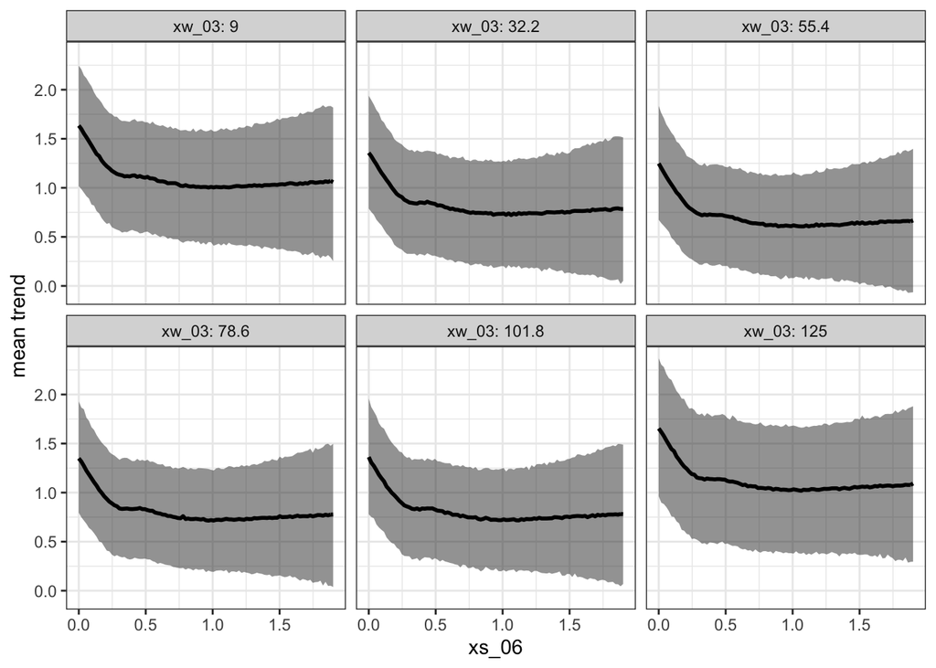

```r
pred_bayes_pred %>%
  ggplot(mapping = aes(x = xs_06)) +
  geom_ribbon(mapping = aes(ymin = trend_lwr,
                            ymax = trend_upr,
                            group = xw_03
                            ),
              alpha = 0.5) +

  geom_line(mapping = aes(y = trend_avg,
                          group = xw_03
                          #color = as.factor(xw_03)),
                          ),
            size = 1.) +
  facet_wrap(~xw_03, labeller = "label_both") +
  scale_fill_viridis_d("xw_03") +
  scale_color_viridis_d("xw_03") +
  labs(y = "mean trend") +
  theme_bw() +
  theme(legend.position = "top")
```

```r
pred_bayes_conf <- pred_bayes %>%
  as.data.frame() %>% tibble::as_tibble() %>%
  tibble::rowid_to_column("post_id") %>%
  pivot_longer(!c("post_id"), names_to = 'pred_id') %>%
  mutate(across(.cols = 'pred_id', .fns = as.numeric)) %>%
  group_by(pred_id) %>%
  summarise(num_post = n(),
            trend_avg = mean(value),
            trend_lwr = quantile(value, 0.05),
            trend_upr = quantile(value, 0.95)) %>%
  ungroup() %>%
  left_join(viz_grid %>% tibble::rowid_to_column("pred_id"),
            by = "pred_id")



pred_bayes_conf %>% head()
```

```
## # A tibble: 6 × 40
##   pred_id num_post trend_avg trend_lwr trend_upr xs_06 xw_03 xb_01 xb_02 xb_03
##     <dbl>    <int>     <dbl>     <dbl>     <dbl> <dbl> <dbl> <dbl> <dbl> <dbl>
## 1       1     4000      1.64      1.25      2.02 0         9  3.25     6     1
## 2       2     4000      1.60      1.22      1.97 0.019     9  3.25     6     1
## 3       3     4000      1.55      1.19      1.91 0.038     9  3.25     6     1
## 4       4     4000      1.51      1.16      1.86 0.057     9  3.25     6     1
## 5       5     4000      1.47      1.13      1.80 0.076     9  3.25     6     1
## 6       6     4000      1.43      1.10      1.76 0.095     9  3.25     6     1
## # … with 30 more variables: xb_04 <dbl>, xb_05 <dbl>, xb_06 <dbl>, xb_07 <dbl>,
## #   xb_08 <dbl>, xn_01 <dbl>, xn_02 <dbl>, xn_03 <dbl>, xn_04 <dbl>,
## #   xn_05 <dbl>, xn_06 <dbl>, xn_07 <dbl>, xn_08 <dbl>, xa_01 <dbl>,
## #   xa_02 <dbl>, xa_03 <dbl>, xa_04 <dbl>, xa_05 <dbl>, xa_06 <dbl>,
## #   xa_07 <dbl>, xa_08 <dbl>, xw_01 <dbl>, xw_02 <dbl>, xs_01 <dbl>,
## #   xs_02 <dbl>, xs_03 <dbl>, xs_04 <dbl>, xs_05 <dbl>, region <chr>,
## #   customer <chr>
```

*Confidence Interval Graphics*

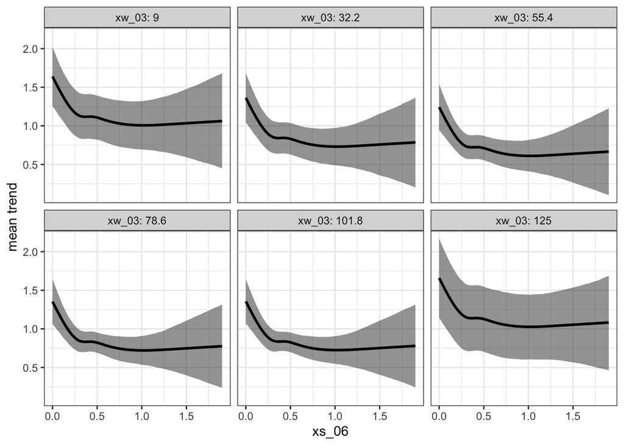

```r
pred_bayes_conf %>%
  ggplot(mapping = aes(x = xs_06)) +
  geom_ribbon(mapping = aes(ymin = trend_lwr,
                            ymax = trend_upr,
                            group = xw_03
                            ),
              alpha = 0.5) +

  geom_line(mapping = aes(y = trend_avg,
                          group = xw_03
                          #color = as.factor(xw_03)),
                          ),
            size = 1.) +
  facet_wrap(~xw_03, labeller = "label_both") +
  scale_fill_viridis_d("xw_03") +
  scale_color_viridis_d("xw_03") +
  labs(y = "mean trend") +
  theme_bw() +
  theme(legend.position = "top")
```

The model is very confident around the middle of the inputs, with a narrow ribbon that grows wides at the edges of the input. As you can see, the trend is non-linear.

**All Additive Winning Model**

```r
viz_grid_lm_all <- expand.grid(xb_04 = seq(-2, 5, length.out = 101),
                        xn_04 = seq(-4, 5, length.out = 6),
                        xb_01 = median(dfii$xb_01),
                        xb_02 = median(dfii$xb_02),
                        xb_03 = median(dfii$xb_03),
                        #xb_04 = median(dfii$xb_04),
                        xb_05 = median(dfii$xb_05),
                        xb_06 = median(dfii$xb_06),
                        xb_07 = median(dfii$xb_07),
                        xb_08 = median(dfii$xb_08),
                        xn_01 = median(dfii$xn_01),
                        xn_02 = median(dfii$xn_02),
                        xn_03 = median(dfii$xn_03),
                        #xn_04 = median(dfii$xn_04),
                        xn_05 = median(dfii$xn_05),
                        xn_06 = median(dfii$xn_06),
                        xn_07 = median(dfii$xn_07),
                        xn_08 = median(dfii$xn_08),
                        xa_01 = median(dfii$xa_01),
                        xa_02 = median(dfii$xa_02),
                        xa_03 = median(dfii$xa_03),
                        xa_04 = median(dfii$xa_04),
                        xa_05 = median(dfii$xa_05),
                        xa_06 = median(dfii$xa_06),
                        xa_07 = median(dfii$xa_07),
                        xa_08 = median(dfii$xa_08),
                        xw_01 = median(dfii$xw_01),
                        xw_02 = median(dfii$xw_02),
                        xw_03 = median(dfii$xw_03),
                        xs_01 = median(dfii$xs_01),
                        xs_02 = median(dfii$xs_02),
                        xs_03 = median(dfii$xs_03),
                        xs_04 = median(dfii$xs_04),
                        xs_05 = median(dfii$xs_05),
                        xs_06 = median(dfii$xs_06),
                        region = "ZZ",
                        customer = "K",
                        KEEP.OUT.ATTRS = FALSE,
                        stringsAsFactors = FALSE) %>%
  as.data.frame() %>% tibble::as_tibble()

viz_grid_lm_all %>% glimpse()
```

```
## Rows: 606
## Columns: 35
## $ xb_04    <dbl> -2.00, -1.93, -1.86, -1.79, -1.72, -1.65, -1.58, -1.51, -1.44…
## $ xn_04    <dbl> -4, -4, -4, -4, -4, -4, -4, -4, -4, -4, -4, -4, -4, -4, -4, -…
## $ xb_01    <dbl> 3.25, 3.25, 3.25, 3.25, 3.25, 3.25, 3.25, 3.25, 3.25, 3.25, 3…
## $ xb_02    <dbl> 6, 6, 6, 6, 6, 6, 6, 6, 6, 6, 6, 6, 6, 6, 6, 6, 6, 6, 6, 6, 6…
## $ xb_03    <dbl> 1, 1, 1, 1, 1, 1, 1, 1, 1, 1, 1, 1, 1, 1, 1, 1, 1, 1, 1, 1, 1…
## $ xb_05    <dbl> 0.4, 0.4, 0.4, 0.4, 0.4, 0.4, 0.4, 0.4, 0.4, 0.4, 0.4, 0.4, 0…
## $ xb_06    <dbl> 2, 2, 2, 2, 2, 2, 2, 2, 2, 2, 2, 2, 2, 2, 2, 2, 2, 2, 2, 2, 2…
## $ xb_07    <dbl> 2, 2, 2, 2, 2, 2, 2, 2, 2, 2, 2, 2, 2, 2, 2, 2, 2, 2, 2, 2, 2…
## $ xb_08    <dbl> 0.2051282, 0.2051282, 0.2051282, 0.2051282, 0.2051282, 0.2051…
## $ xn_01    <dbl> 1.6, 1.6, 1.6, 1.6, 1.6, 1.6, 1.6, 1.6, 1.6, 1.6, 1.6, 1.6, 1…
## $ xn_02    <dbl> 4, 4, 4, 4, 4, 4, 4, 4, 4, 4, 4, 4, 4, 4, 4, 4, 4, 4, 4, 4, 4…
## $ xn_03    <dbl> -1, -1, -1, -1, -1, -1, -1, -1, -1, -1, -1, -1, -1, -1, -1, -…
## $ xn_05    <dbl> -0.25, -0.25, -0.25, -0.25, -0.25, -0.25, -0.25, -0.25, -0.25…
```

[output cut: 22 more lines]

```r
tidy_predict <- function(mod, xnew)
{
  pred_df <- predict(mod, xnew, interval = "confidence") %>%
    as.data.frame() %>% tibble::as_tibble() %>%
    dplyr::select(pred = fit, ci_lwr = lwr, ci_upr = upr) %>%
    bind_cols(predict(mod, xnew, interval = 'prediction') %>%
                as.data.frame() %>% tibble::as_tibble() %>%
                dplyr::select(pred_lwr = lwr, pred_upr = upr))

  xnew %>% bind_cols(pred_df)
}
```

```r
pred_lm_all_add <- tidy_predict(re_lm_all_add, viz_grid_lm_all)
```

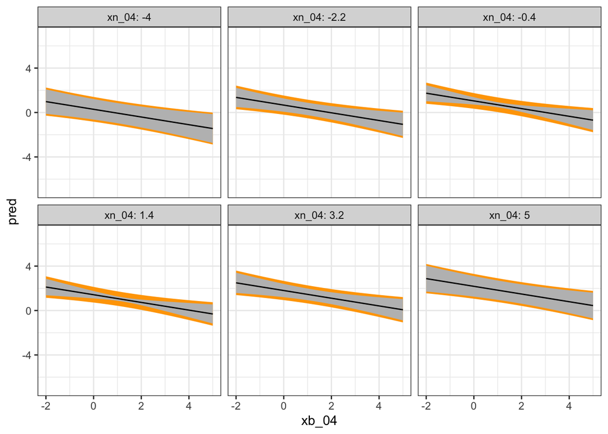

```r
pred_lm_all_add %>%
  ggplot(mapping = aes(x = xb_04)) +
  geom_ribbon(mapping = aes(ymin = pred_lwr, ymax = pred_upr),
              fill = 'orange') +
  geom_ribbon(mapping = aes(ymin = ci_lwr, ymax = ci_upr),
              fill = 'grey') +
  geom_line(mapping = aes(y = pred),
            color = 'black') +
  coord_cartesian(ylim = c(-7, 7)) +
  facet_wrap(~xn_04, labeller = "label_both") +
  theme_bw()
```

The trends are much more linear, and appear to have a negative slope as the inputs increase in value. Once again the confidence ribbon grows wider at the edges of the input showing less confidence at the edges.